# Math 421 - Midterm

## III. Predictive Models

Continue with the data from part I. Make sure you do not have any missing values in the data. Use the follows as the target and input variables:

*Target Variable*: Create the target variable taking value of

- `low` if the total charge of a patient (`tot`) is smaller than the median of the total charge, and
- `high` otherwise.

*Input Variables*:

- “age”,“sex”,“raceethn”,“provider”,“moa”,“mod”,“admtype”,“campus”, ‘los’
1. Use `filter` function to filter out rows where `raceethn==''` or `admtype==''`. Make sure all the categorical variables are factor, numeric variables are numeric. Set Training : Testing Split = 10 : 90

```r
model_data <- hdd_2018_selected %>%
  select(
    tot,
    age, sex, raceethn, provider, moa, mod,
    admtype, campus, los
  )
model_data <- model_data %>%
  filter(complete.cases(.))
model_data <- model_data %>%
  filter(
    raceethn != "",
    admtype != ""
  )
median_tot <- median(model_data$tot)

model_data <- model_data %>%
  mutate(
    target = ifelse(tot < median_tot, "low", "high")
  )
model_data <- model_data %>%
  mutate(
    sex = factor(sex),
    raceethn = factor(raceethn),
    provider = factor(provider),
    moa = factor(moa),
    mod = factor(mod),
    admtype = factor(admtype),
    campus = factor(campus),
    target = factor(target)
  )
colSums(is.na(model_data))
```

```
##      tot      age      sex raceethn provider      moa      mod  admtype
##        0        0        0        0        0        0        0        0
##   campus      los   target
##        0        0        0
```

```r
set.seed(123)

n <- nrow(model_data)
train_index <- sample(seq_len(n), size = 0.10 * n)

train_data <- model_data[train_index, ]
test_data  <- model_data[-train_index, ]

dim(train_data)
```

```
## [1] 12752    11
```

```r
dim(test_data)
```

```
## [1] 114775     11
```

```r
prop.table(table(train_data$target))
```

```
##
##     high      low
## 0.495138 0.504862
```

```r
prop.table(table(test_data$target))
```

```
##
##      high       low
## 0.5005533 0.4994467
```

2. Train a decision tree using `rpart`. Plot the decision tree. Plot the variable importance ranked by the tree.

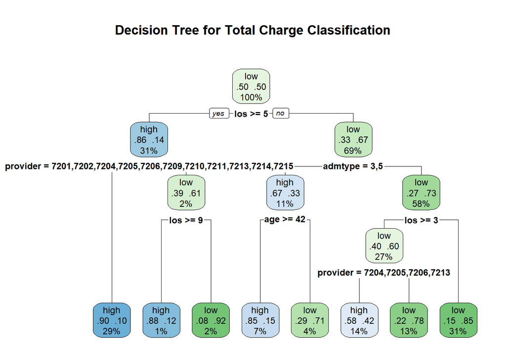

```r
library(rpart)
library(rpart.plot)

set.seed(123)

tree_model <- rpart(
  target ~ age + sex + raceethn + provider + moa + mod +
    admtype + campus + los,
  data = train_data,
  method = "class"
)

rpart.plot(
  tree_model,
  type = 2,
  extra = 104,
  fallen.leaves = TRUE,
  main = "Decision Tree for Total Charge Classification"
)
```

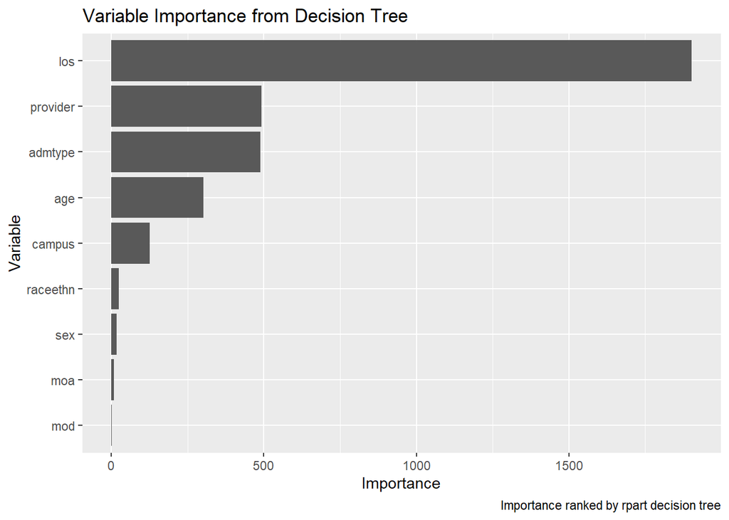

```r
var_imp <- tree_model$variable.importance

var_imp_df <- data.frame(
  variable = names(var_imp),
  importance = as.numeric(var_imp)
) %>%
  arrange(desc(importance))

library(ggplot2)

ggplot(var_imp_df, aes(x = reorder(variable, importance), y = importance)) +
  geom_col() +
  coord_flip() +
  labs(
    title = "Variable Importance from Decision Tree",
    x = "Variable",
    y = "Importance",
    caption = "Importance ranked by rpart decision tree"
  )
```

3. Using caret for this question. Set `Training Control` to be: Use Cross-Validation of 5 folds across all models. Train & tune at least 2 different models (i.e. two different values for `method=` in the train function of caret). Plot the hyper-parameter tuning plots for each model.

```r
library(caret)
set.seed(123)

train_ctrl <- trainControl(
  method = "cv",
  number = 5,
  classProbs = TRUE
)

set.seed(123)

model_rpart <- train(
  target ~ age + sex + raceethn + provider + moa + mod +
    admtype + campus + los,
  data = train_data,
  method = "rpart",
  trControl = train_ctrl,
  tuneLength = 10
)
model_rpart
```

```
## CART
##
## 12752 samples
##     9 predictor
##     2 classes: 'high', 'low'
##
## No pre-processing
## Resampling: Cross-Validated (5 fold)
## Summary of sample sizes: 10201, 10202, 10202, 10202, 10201
## Resampling results across tuning parameters:
##
##   cp           Accuracy   Kappa
##   0.001425404  0.8255983  0.6508747
##   0.001504593  0.8248925  0.6494355
##   0.002534051  0.8235594  0.6467848
##   0.002639637  0.8224617  0.6445909
##   0.004751346  0.8175993  0.6348913
##   0.008789990  0.8095211  0.6185127
##   0.012828635  0.7848195  0.5686255
##   0.031358885  0.7743901  0.5478944
##   0.071111815  0.7497640  0.4982934
##   0.455495724  0.5922003  0.1777985
##
## Accuracy was used to select the optimal model using the largest value.
## The final value used for the model was cp = 0.001425404.
```

```r
plot(model_rpart) +
  labs(
    title = "Hyper-Parameter Tuning: Decision Tree (rpart)",
    x = "Complexity Parameter (cp)",
    y = "Accuracy"
  )
```

[output not shown]

```r
#2
model_rf <- train(
  target ~ age + sex + raceethn + provider + moa + mod +
    admtype + campus + los,
  data = train_data,
  method = "ranger",
  trControl = train_ctrl,
  tuneLength = 5,
  importance = "impurity"
)
model_rf
```

```
## Random Forest
##
## 12752 samples
##     9 predictor
##     2 classes: 'high', 'low'
##
## No pre-processing
## Resampling: Cross-Validated (5 fold)
## Summary of sample sizes: 10202, 10202, 10202, 10201, 10201
## Resampling results across tuning parameters:
##
##   mtry  splitrule   Accuracy   Kappa
##    2    gini        0.7910120  0.5819674
##    2    extratrees  0.7029492  0.4065468
##   14    gini        0.8237127  0.6472625
##   14    extratrees  0.8172042  0.6343148
##   26    gini        0.8163420  0.6325658
##   26    extratrees  0.8150871  0.6300659
##   38    gini        0.8121076  0.6241040
##   38    extratrees  0.8096763  0.6192512
##   51    gini        0.8090493  0.6179982
##   51    extratrees  0.8071670  0.6142445
##
## Tuning parameter 'min.node.size' was held constant at a value of 1
## Accuracy was used to select the optimal model using the largest value.
## The final values used for the model were mtry = 14, splitrule = gini
##  and min.node.size = 1.
```

```r
plot(model_rf) +
  labs(
    title = "Hyper-Parameter Tuning: Random Forest (ranger)",
    x = "mtry",
    y = "Accuracy"
  )
```

[output not shown]

4. Plot the comparison of the models in 3.

```r
model_list <- resamples(list(
  Decision_Tree = model_rpart,
  Random_Forest = model_rf
))
summary(model_list)
```

```
##
## Call:
## summary.resamples(object = model_list)
##
## Models: Decision_Tree, Random_Forest
## Number of resamples: 5
##
## Accuracy
##                    Min.   1st Qu.    Median      Mean   3rd Qu.      Max. NA's
## Decision_Tree 0.8008624 0.8212466 0.8301961 0.8255983 0.8349020 0.8407843    0
## Random_Forest 0.8078431 0.8200000 0.8278431 0.8237127 0.8294786 0.8333987    0
##
## Kappa
##                    Min.   1st Qu.    Median      Mean   3rd Qu.      Max. NA's
## Decision_Tree 0.6013067 0.6421839 0.6600986 0.6508747 0.6695026 0.6812816    0
## Random_Forest 0.6154372 0.6398804 0.6555261 0.6472625 0.6588904 0.6665783    0
```

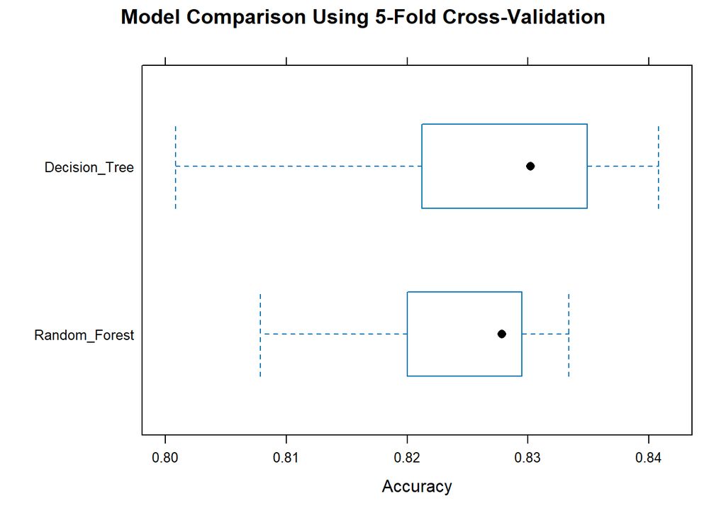

```r
bwplot(
  model_list,
  metric = "Accuracy",
  main = "Model Comparison Using 5-Fold Cross-Validation"
)
```

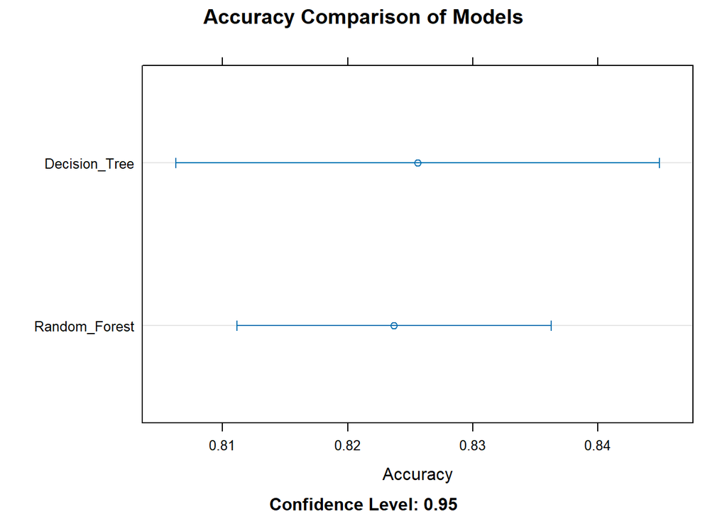

```r
dotplot(
  model_list,
  metric = "Accuracy",
  main = "Accuracy Comparison of Models"
)
```

5. What is your final selection for the model? Test the accuracy of your final model on the test data.

```r
rf_predictions <- predict(model_rf, newdata = test_data)
conf_mat <- confusionMatrix(
  rf_predictions,
  test_data$target
)

conf_mat
```

```
## Confusion Matrix and Statistics
##
##           Reference
## Prediction  high   low
##       high 46359  8559
##       low  11092 48765
##
##                Accuracy : 0.8288
##                  95% CI : (0.8266, 0.831)
##     No Information Rate : 0.5006
##     P-Value [Acc > NIR] : < 2.2e-16
##
##                   Kappa : 0.6576
##
##  Mcnemar's Test P-Value : < 2.2e-16
##
##             Sensitivity : 0.8069
##             Specificity : 0.8507
##          Pos Pred Value : 0.8441
##          Neg Pred Value : 0.8147
##              Prevalence : 0.5006
##          Detection Rate : 0.4039
##    Detection Prevalence : 0.4785
##       Balanced Accuracy : 0.8288
##
##        'Positive' Class : high
##
```